# Anime Rating Predictions

Clayton Ramsey

November 17, 2020

# A Regression Model for Predicting Anime Ratings

## Data Description

The data was retrieved from [Kaggle](https://www.kaggle.com/CooperUnion/anime-recommendations-database). It consists of user-generated ratings for 12294 anime productions such as TV shows, movies, and OVAs.

I read the data and performed some cleaning tasks. First, I had to convert the column representing number of episodes back to numeric. Some cells contained the word “unknown”, and this caused R to coerce the column to character. I chose to keep only complete cases in order to simplify the analysis.

This is the head of the data frame produced by this step:

| anime_id | name | genre | type | episodes | rating | members |
| --- | --- | --- | --- | --- | --- | --- |
| 32281 | Kimi no Na wa. | Drama, Romance, School, Supernatural | Movie | 1 | 9.37 | 200630 |
| 5114 | Fullmetal Alchemist: Brotherhood | Action, Adventure, Drama, Fantasy, Magic, Military, Shounen | TV | 64 | 9.26 | 793665 |
| 28977 | Gintama° | Action, Comedy, Historical, Parody, Samurai, Sci-Fi, Shounen | TV | 51 | 9.25 | 114262 |
| 9253 | Steins;Gate | Sci-Fi, Thriller | TV | 24 | 9.17 | 673572 |
| 9969 | Gintama' | Action, Comedy, Historical, Parody, Samurai, Sci-Fi, Shounen | TV | 51 | 9.16 | 151266 |
| 32935 | Haikyuu!!: Karasuno Koukou VS Shiratorizawa Gakuen Koukou | Comedy, Drama, School, Shounen, Sports | TV | 10 | 9.15 | 93351 |

As we can see the “genre” column consists of a comma-separated string of genre tags. This isn’t exactly suitable for an analysis, so I did tow more processing steps to clean this data.

First, I separated the genres into discrete names. I wrote a function to split the character strings and applied it to the “genre” column".

Then I made a comprehensive list of all listed genres.

To extract the nth genre of anime r I used `x <- genres[[1]][[r]][n]`.

```r
genre_split <- function(x){
  return(str_split(x, ", "))
}
genres <- apply(matrix(anime$genre), 2, genre_split)
names(genres[[1]]) <- 1:length(genres[[1]])

all_genres <- character()
for(i in 1:length(genres[[1]])){
  for(j in 1:length(genres[[1]][[i]])){
    # Append the genre if it isn't there yet.
    if(!(genres[[1]][[i]][j] %in% all_genres)){
      all_genres <- append(all_genres, genres[[1]][[i]][j])
    }
  }
}
```

Next, I created a new variable that records the number of genres each anime is tagged for. The thinking here is that there may be some connection between the ratings of the anime and its “complexity”, where the number of genres is a proxy for complexity. This variable is bound to the data frame.

The `anime` data frame now looks like this:

| anime_id | name | genre | type | episodes | rating | members | genre_tag_number |
| --- | --- | --- | --- | --- | --- | --- | --- |
| 32281 | Kimi no Na wa. | Drama, Romance, School, Supernatural | Movie | 1 | 9.37 | 200630 | 4 |
| 5114 | Fullmetal Alchemist: Brotherhood | Action, Adventure, Drama, Fantasy, Magic, Military, Shounen | TV | 64 | 9.26 | 793665 | 7 |
| 28977 | Gintama° | Action, Comedy, Historical, Parody, Samurai, Sci-Fi, Shounen | TV | 51 | 9.25 | 114262 | 7 |
| 9253 | Steins;Gate | Sci-Fi, Thriller | TV | 24 | 9.17 | 673572 | 2 |
| 9969 | Gintama' | Action, Comedy, Historical, Parody, Samurai, Sci-Fi, Shounen | TV | 51 | 9.16 | 151266 | 7 |
| 32935 | Haikyuu!!: Karasuno Koukou VS Shiratorizawa Gakuen Koukou | Comedy, Drama, School, Shounen, Sports | TV | 10 | 9.15 | 93351 | 5 |

This table contains the response variable `rating`, variables suitable for predictors, and the variables `anime_id` and `name` which are not used as predictors.

The next step I wanted to make was to create a large data frame containing factor variables representing the presence of the different genres in each anime.

```r
rating_by_genre <- tibble(rating = anime$rating)

for(i in 1:length(all_genres)){
  #create a variable for that genre:
  x <- integer(length(anime$genre))
  #populate the variable:
  for (j in 1:length(anime$genre)){
    x[j] <- all_genres[i] %in% genres[[1]][[j]]
  }
  # Attach the newly created variable to the ratings:
  x <- x %>% as_factor() %>% as_tibble()
  names(x) <- all_genres[i]
  rating_by_genre <- cbind(rating_by_genre, x)
}

rm(i)
rm(j)
```

The table looks like this. I’m only showing the first ten genres for illustration purposes but there are actually forty-three of them.

| rating | Drama | Romance | School | Supernatural | Action | Adventure | Fantasy | Magic | Military |
| --- | --- | --- | --- | --- | --- | --- | --- | --- | --- |
| 9.37 | 1 | 1 | 1 | 1 | 0 | 0 | 0 | 0 | 0 |
| 9.26 | 1 | 0 | 0 | 0 | 1 | 1 | 1 | 1 | 1 |
| 9.25 | 0 | 0 | 0 | 0 | 1 | 0 | 0 | 0 | 0 |
| 9.17 | 0 | 0 | 0 | 0 | 0 | 0 | 0 | 0 | 0 |
| 9.16 | 0 | 0 | 0 | 0 | 1 | 0 | 0 | 0 | 0 |
| 9.15 | 1 | 0 | 1 | 0 | 0 | 0 | 0 | 0 | 0 |

## Visualizations

Looking at the correlations of the numeric variables:

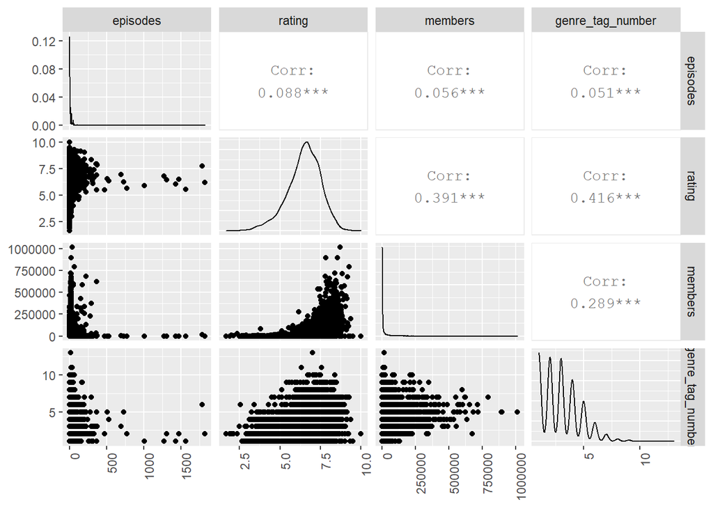

The `members` variable is interesting here because it has some sort of association with `rating` but it isn’t really suitable for a predictor variable. This is because the ratings and membership have a mutually influential relationship. The variable `members` is the “number of community members that are in this anime’s group” on myanimelist.net. It is likely that “better” anime has more of a following, leading to more group members. So in some sense, the group membership responds to ratings, not the other way around. But also, the more people in the group could mean more exposure, gaining visibility for that anime. This could cause people to view the anime and rate it. And if there are more people in the group, it is likely to be better in the first place, leading to better ratings.

Popularity and quality, represented by the variables `members` and `rating` are associated and both suitable for response variables. But it isn’t wise to use one for a predictor of the other. Not only that, the `members` variable isn’t strictly about the anime - it has to do with members of a website and so is at a remove from the characteristics of the anime itself.

Here is a scatter plot of the `rating` variable against the `members` variable. For anime with more members, the positive relationship is more pronounced and the variance is smaller, possibly representing a process of forming consensus.

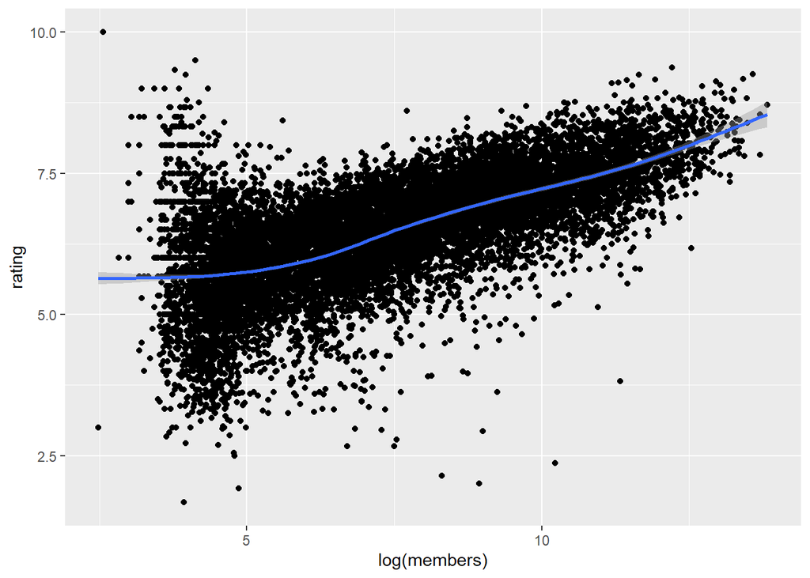

The type appears to have some effect on the mean ratings:

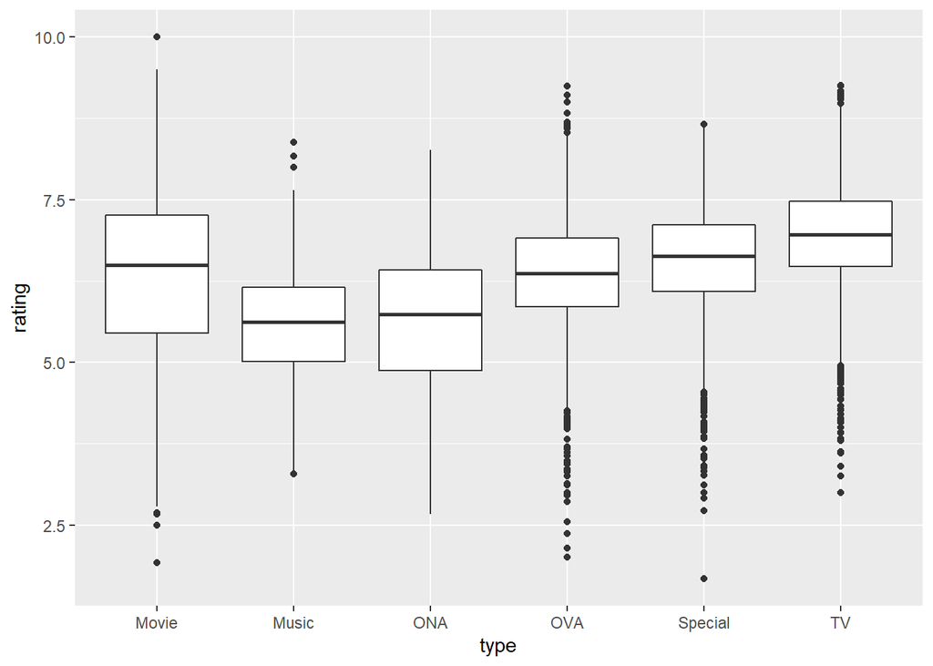

| Type | Mean Rating |
| --- | --- |
| Movie | 6.334486 |
| Music | 5.588665 |
| ONA | 5.640479 |
| OVA | 6.371087 |
| Special | 6.525454 |
| TV | 6.929487 |

The average rating for different numbers of genre tags shows a potentially quadratic relationship:

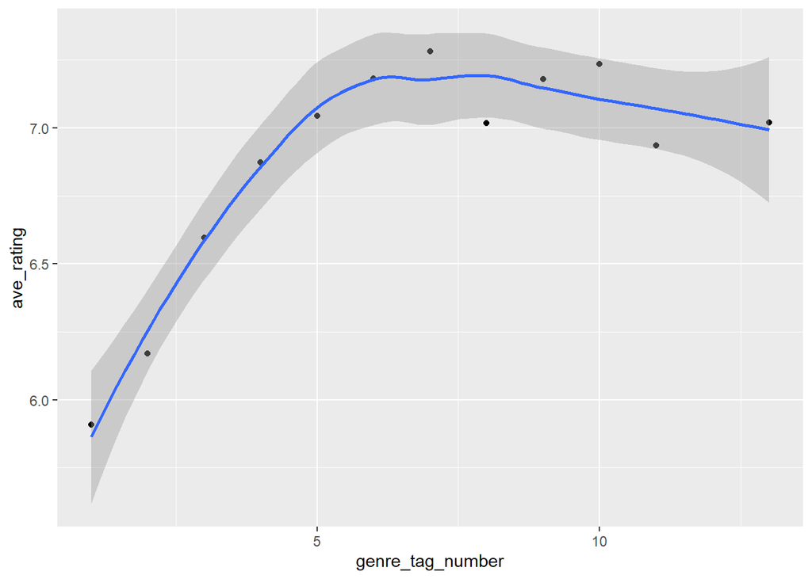

Also, the rating seems to respond to the number of episodes:

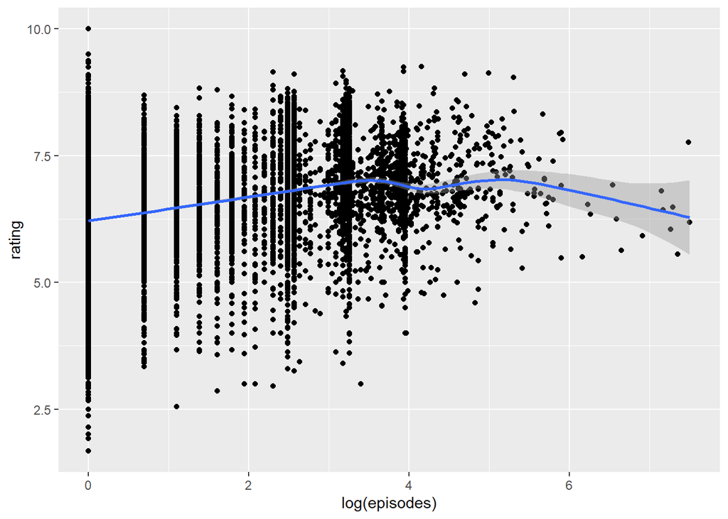

```r
er <- ggplot(data = anime, aes(x = log(episodes), y = rating)) + geom_point() + geom_smooth()
er
```

## Creating models

I began by dividing the dataset into testing and training sections at a 3 to 7 ratio.

```r
numrows <- length(anime$rating)
training_indices <- sample(1:numrows, round(0.7*numrows), replace = FALSE)
testing_indices <- setdiff(1:numrows, training_indices)
```

### A genre-based model

The first model I tried was just by dropping all the genre factors into the formula and then proceeding with backwards elimination. I then generated predictions from this model.

```r
genremodel <- glm(rating ~ ., data = rating_by_genre[training_indices,])
genremodel <- step(genremodel)
```

```
## Start:  AIC=21230.21
## rating ~ Drama + Romance + School + Supernatural + Action + Adventure +
##     Fantasy + Magic + Military + Shounen + Comedy + Historical +
##     Parody + Samurai + `Sci-Fi` + Thriller + Sports + `Super Power` +
##     Space + `Slice of Life` + Mecha + Music + Mystery + Seinen +
##     `Martial Arts` + Vampire + Shoujo + Horror + Police + Psychological +
##     Demons + Ecchi + Josei + `Shounen Ai` + Game + Dementia +
##     Harem + Cars + Kids + `Shoujo Ai` + Hentai + Yaoi + Yuri
##
##                   Df Deviance   AIC
## - Mecha            1   6227.3 21228
## - Yuri             1   6227.5 21228
## - `Martial Arts`   1   6227.6 21229
## - Yaoi             1   6227.6 21229
## - Vampire          1   6227.6 21229
## - Cars             1   6227.8 21229
## - Parody           1   6227.9 21229
## - Space            1   6228.0 21229
## - `Shoujo Ai`      1   6228.4 21230
## - Samurai          1   6228.4 21230
## - Ecchi            1   6228.5 21230
## - Demons           1   6228.6 21230
## <none>                 6227.3 21230
## - `Shounen Ai`     1   6230.4 21232
## - Harem            1   6231.3 21234
## - Magic            1   6234.1 21237
## - Thriller         1   6235.1 21239
## - Game             1   6235.6 21239
## - Hentai           1   6239.8 21245
## - Police           1   6241.7 21247
## - Horror           1   6241.8 21247
## - `Super Power`    1   6242.9 21249
## - Josei            1   6244.9 21252
## - Music            1   6247.6 21255
## - Kids             1   6248.5 21256
## - `Sci-Fi`         1   6250.3 21259
## - Psychological    1   6252.5 21262
## - Historical       1   6255.3 21265
## - Sports           1   6255.4 21266
## - Action           1   6256.4 21267
```

[output cut: 575 more lines]

```
## - Action           1   6267.3 21257
## - Historical       1   6269.1 21260
## - Adventure        1   6273.6 21266
## - Seinen           1   6279.6 21273
## - Military         1   6285.6 21281
## - Supernatural     1   6286.3 21282
## - Romance          1   6288.3 21285
## - Fantasy          1   6288.6 21285
## - Comedy           1   6297.6 21297
## - `Slice of Life`  1   6302.1 21303
## - Mystery          1   6316.7 21322
## - School           1   6325.0 21333
## - Dementia         1   6377.3 21401
## - Shounen          1   6391.1 21419
## - Drama            1   6415.3 21451
```

```r
summary(genremodel)
```

```
##
## Call:
## glm(formula = rating ~ Drama + Romance + School + Supernatural +
##     Action + Adventure + Fantasy + Magic + Military + Shounen +
##     Comedy + Historical + `Sci-Fi` + Thriller + Sports + `Super Power` +
##     `Slice of Life` + Music + Mystery + Seinen + Shoujo + Horror +
##     Police + Psychological + Josei + `Shounen Ai` + Game + Dementia +
##     Harem + Kids + Hentai, data = rating_by_genre[training_indices,
##     ])
##
## Deviance Residuals:
##     Min       1Q   Median       3Q      Max
## -4.2993  -0.4940   0.0535   0.5719   3.2860
##
## Coefficients:
##                  Estimate Std. Error t value Pr(>|t|)
## (Intercept)       5.89416    0.02428 242.798  < 2e-16 ***
## Drama1            0.42429    0.02746  15.453  < 2e-16 ***
## Romance1          0.27590    0.03281   8.410  < 2e-16 ***
## School1           0.37892    0.03468  10.925  < 2e-16 ***
## Supernatural1     0.30470    0.03692   8.253  < 2e-16 ***
## Action1           0.17174    0.02621   6.554 5.96e-11 ***
## Adventure1        0.19159    0.02676   7.160 8.75e-13 ***
## Fantasy1          0.22991    0.02724   8.439  < 2e-16 ***
## Magic1            0.11912    0.04163   2.861  0.00423 **
## Military1         0.43751    0.05337   8.197 2.83e-16 ***
## Shounen1          0.44215    0.03075  14.378  < 2e-16 ***
## Comedy1           0.20492    0.02248   9.117  < 2e-16 ***
## Historical1       0.27372    0.04065   6.734 1.76e-11 ***
## `Sci-Fi`1         0.17797    0.02833   6.283 3.50e-10 ***
## Thriller1         0.37141    0.11514   3.226  0.00126 **
## Sports1           0.30028    0.05029   5.971 2.45e-09 ***
## `Super Power`1    0.23977    0.05091   4.709 2.53e-06 ***
## `Slice of Life`1  0.31984    0.03391   9.432  < 2e-16 ***
## Music1           -0.20751    0.03978  -5.217 1.87e-07 ***
## Mystery1          0.52944    0.05087  10.409  < 2e-16 ***
## Seinen1           0.36112    0.04694   7.693 1.60e-14 ***
## Shoujo1           0.30159    0.04678   6.447 1.20e-10 ***
## Horror1          -0.26952    0.05910  -4.560 5.18e-06 ***
## Police1           0.32743    0.07653   4.279 1.90e-05 ***
## Psychological1    0.42161    0.07257   5.810 6.50e-09 ***
## Josei1            0.71916    0.14475   4.968 6.89e-07 ***
## `Shounen Ai`1     0.29363    0.14277   2.057  0.03975 *
## Game1             0.25614    0.07875   3.253  0.00115 **
## Dementia1        -0.96507    0.07030 -13.729  < 2e-16 ***
## Harem1            0.13001    0.06254   2.079  0.03765 *
## Kids1            -0.16584    0.03084  -5.378 7.75e-08 ***
## Hentai1           0.15337    0.03867   3.966 7.38e-05 ***
## ---
## Signif. codes:  0 '***' 0.001 '**' 0.01 '*' 0.05 '.' 0.1 ' ' 1
##
## (Dispersion parameter for gaussian family taken to be 0.7558269)
##
##     Null deviance: 8632.8  on 8280  degrees of freedom
## Residual deviance: 6234.8  on 8249  degrees of freedom
## AIC: 21216
##
## Number of Fisher Scoring iterations: 2
```

```r
ratings_predict <- predict(genremodel, rating_by_genre[testing_indices,])
ratings_actual <- rating_by_genre$rating[testing_indices]
```

### A characteristics-based model

This model uses a quadratic function of the number of genre tags, the log of the number of episodes, and the type factor as predictors.

```r
model_2 <- glm(rating ~ genre_tag_number + I(genre_tag_number^2) + I(log(episodes)) + type,
               data = anime[training_indices,])
summary(model_2)
```

```
##
## Call:
## glm(formula = rating ~ genre_tag_number + I(genre_tag_number^2) +
##     I(log(episodes)) + type, data = anime[training_indices, ])
##
## Deviance Residuals:
##     Min       1Q   Median       3Q      Max
## -4.4977  -0.5150   0.0332   0.5823   3.6554
##
## Coefficients:
##                        Estimate Std. Error t value Pr(>|t|)
## (Intercept)            5.485954   0.038325 143.143  < 2e-16 ***
## genre_tag_number       0.382853   0.019588  19.545  < 2e-16 ***
## I(genre_tag_number^2) -0.024204   0.002519  -9.607  < 2e-16 ***
## I(log(episodes))       0.135503   0.014047   9.646  < 2e-16 ***
## typeMusic             -0.509686   0.052594  -9.691  < 2e-16 ***
## typeONA               -0.640957   0.050502 -12.692  < 2e-16 ***
## typeOVA               -0.012905   0.029962  -0.431 0.666681
## typeSpecial            0.127843   0.034783   3.675 0.000239 ***
## typeTV                 0.023407   0.052675   0.444 0.656791
## ---
## Signif. codes:  0 '***' 0.001 '**' 0.01 '*' 0.05 '.' 0.1 ' ' 1
##
## (Dispersion parameter for gaussian family taken to be 0.7735343)
##
##     Null deviance: 8632.8  on 8280  degrees of freedom
## Residual deviance: 6398.7  on 8272  degrees of freedom
## AIC: 21385
##
## Number of Fisher Scoring iterations: 2
```

```r
ratings_predict_2 <- predict(model_2, anime[testing_indices,])
rating_summary <- tibble(actual = ratings_actual, pred1 = ratings_predict, pred2 = ratings_predict_2)

head(rating_summary)
```

| actual | pred1 | pred2 |
| --- | --- | --- |
| 9.16 | 7.164665 | 7.536123 |
| 9.10 | 7.164665 | 6.979941 |
| 9.11 | 7.164665 | 7.350907 |
| 8.93 | 7.644729 | 7.254700 |
| 8.84 | 6.443908 | 6.154845 |
| 8.83 | 7.265804 | 7.238546 |

### A hybrid model

```r
anime_allvars <- cbind(rating_by_genre[,-1], anime)

model_3 <- update(genremodel, . ~ . + genre_tag_number + I(genre_tag_number^2) + type,
                  data = anime_allvars[training_indices,])
ratings_predict_3 <- predict(model_3, anime_allvars[testing_indices,])
```

## Examining the predictions

My first step is examining the root means squared error and mean absolute percent error of all three model predictions.

```r
rmse(ratings_actual, ratings_predict)
```

```
## [1] 0.8639592
```

```r
rmse(ratings_actual, ratings_predict_2)
```

```
## [1] 0.8808165
```

```r
rmse(ratings_actual, ratings_predict_3)
```

```
## [1] 0.834157
```

```r
mape(ratings_actual, ratings_predict)
```

```
## [1] 0.1120576
```

```r
mape(ratings_actual, ratings_predict_2)
```

```
## [1] 0.1144985
```

```r
mape(ratings_actual, ratings_predict_3)
```

```
## [1] 0.1076837
```